# assignment05

Jeff Nguyen

18/09/2020

**University of Southern California**  
**Marshall School of Business**  
**FBE 506 Quantitative Method in Finance**

Assignment 05  
Student Name: Ngoc Son (Jeff) Nguyen  
Student ID: 6524885309

# **Question 1**

```r
library(quantmod)
# Set start date and end date of data
start_date <- "2014-01-02"
end_date <- "2020-09-18"

# Get data for JPM, FB and the 10 year T-bill (TNX)
getSymbols("JPM", src = "yahoo", from = start_date, to = end_date) # JPM
```

[output not shown]

```
## [1] "JPM"
```

```r
getSymbols("FB", src = "yahoo", , from = start_date, to = end_date) # FB
```

```
## [1] "FB"
```

```r
getSymbols("^TNX", src = "yahoo", from = start_date, to = end_date) # TNX (10-year T-bill)
```

```
## [1] "^TNX"
```

```r
# Get adjusted returns data for 01/2014
rJPM <- diff(log(to.monthly(JPM)$JPM.Adjusted))
rFB <- diff(log(to.monthly(FB)$FB.Adjusted))
rTNX <- (to.monthly(TNX)$TNX.Adjusted) / 1200 # Using monthly rate
# Calculate statistics
mean_rJPM <- mean(rJPM, na.rm = TRUE)
mean_rFB <- mean(rFB, na.rm = TRUE)
mean_rTNX <- mean(rTNX, na.rm = TRUE)

sd_rJPM <- sd(rJPM, na.rm = TRUE)
sd_rFB <- sd(rFB, na.rm = TRUE)
```

## a. Coefficient of variation

For JPM:

```r
# Coefficient of variation of Adjusted Returns of JPM
cv_rJPM <- sd_rJPM / mean_rJPM
```

$$\begin{equation}
\begin{aligned}
CV_{JPM} & = \frac{\sigma}{\mu} \\
& = \frac{0.0649717}{0.0095089} \\
& = 6.8327559 \\
\text {where} \\
\sigma & = \text {Standard deviation of Adjusted Returns} \\
\mu & = \text {Mean of Adjusted Returns} \\
\end{aligned}
\end{equation}$$

For FB:

```r
# Coefficient of variation of Adjusted Returns of FB
cv_rFB <- sd_rFB / mean_rFB
```

$$\begin{equation}
\begin{aligned}
CV_{FB} & = \frac{\sigma}{\mu} \\
& = \frac{0.0744548}{0.0175534} \\
& = 4.2416176 \\
\text {where} \\
\sigma & = \text {Standard deviation of Adjusted Returns} \\
\mu & = \text {Mean of Adjusted Returns } \\
\end{aligned}
\end{equation}$$

## b. Sharpe Ratio

In this case, each portfolio carry 100% of JPM of FB so weighting is 100% of each stock for each portfolio.

For JPM:

```r
# Sharpe Ratio of a 100% JPM portfolio
sharpe_rJPM <- (mean_rJPM - mean_rTNX) / sd_rJPM
```

$$\begin{equation}
\begin{aligned}
S_{JPM} & = \frac{E(r_p) - r_f}{\sigma_p} \\
& = \frac{0.0095089 - 0.0017659}{0.0649717} \\
& = 0.1191742 \\
\text {where} \\
r_p & = \text {Mean of Adjusted Returns} \\
r_f & = \text {Risk free rate} \\
\sigma_p & = \text {Standard deviation of adjusted returns}
\end{aligned}
\end{equation}$$

For FB:

```r
# Sharpe Ratio of a 100% JPM portfolio
sharpe_rFB <- (mean_rFB - mean_rTNX) / sd_rFB
```

$$\begin{equation}
\begin{aligned}
S_{FB} & = \frac{E(r_p) - r_f}{\sigma_p} \\
& = \frac{0.0175534 - 0.0017659}{0.0744548} \\
& = 0.2120413 \\
\text {where} \\
r_p & = \text {Mean of Adjusted Returns} \\
r_f & = \text {Risk free rate} \\
\sigma_p & = \text {Standard deviation of adjusted returns}
\end{aligned}
\end{equation}$$

## b. Sortino Ratio

For JPM:

```r
# Calculating downside deviation using lower partial moment of order 2
# Assuming the 10 year T-bill returns as minimum acceptable returns MAR
mar <- mean_rTNX

# Deviation from MAR, this is a data frame, remove NA values
dev_rJPM_mar <- na.omit(rJPM - mar)

# Get the subset of negative values
devNegative_rJPM_mar <- subset(dev_rJPM_mar, dev_rJPM_mar < 0)

# Calculate the Lower Partial Moment
downsideDev_JPM <- var(devNegative_rJPM_mar)

# Downside deviation
sd_downsideDev_JPM <- sqrt(downsideDev_JPM)

# Sortino Ratio
sortino_rJPM <- (mean_rJPM - mean_rTNX) / sd_downsideDev_JPM
```

$$\begin{equation}
\begin{aligned}
SortinoRatio_{JPM} & = \frac{r_p - r_f}{\sigma_{downside}} \\
& = \frac{0.0095089 - 0.0017659}{0.0530044} \\
& = 0.1460813 \\
\text {where} \\
r_p & = \text {Mean of Adjusted Returns} \\
r_f & = \text {Risk free rate} \\
\sigma_{downside} & = \text {Standard deviation of the downside}
\end{aligned}
\end{equation}$$

For FB:

```r
# Calculating downside deviation using lower partial moment of order 2
# Assuming the 10 year T-bill returns as minimum acceptable returns MAR
mar <- mean_rTNX

# Deviation from MAR, this is a data frame, also remove NA values
dev_rFB_mar <- na.omit(rFB - mar)

# Get the subset of negative values
devNegative_rFB_mar <- subset(dev_rFB_mar, dev_rFB_mar < 0)

# Calculate the Lower Partial Moment
downsideDev_FB <- var(devNegative_rFB_mar)

# Downside deviation
sd_downsideDev_FB <- sqrt(downsideDev_FB)

# Sortino Ratio
sortino_rFB <- (mean_rFB - mean_rTNX) / sd_downsideDev_FB
```

In summary:

| Portfolio | Coefficient of Variation | Sharpe Ratio | Sortino Ratio |
| --- | --- | --- | --- |
| JPM | 6.8327559 | 0.1191742 | 0.1460813 |
| FB | 4.2416176 | 0.2120413 | 0.3836041 |

# **Question 2**

```r
# Set start date and end date of data
start_date <- "2018-01-02"
end_date <- "2020-09-18"

# Get data for JPM, FB and the 10 year T-bill (TNX)
getSymbols("JPM", src = "yahoo", from = start_date, to = end_date) # JPM
```

```
## [1] "JPM"
```

```r
getSymbols("FB", src = "yahoo", from = start_date, to = end_date) # FB
```

```
## [1] "FB"
```

```r
getSymbols("^TNX", src = "yahoo", from = start_date, to = end_date) # TNX (10-year T-bill)
```

```
## [1] "^TNX"
```

```r
# Get adjusted returns data for 01/2014
rJPM <- diff(log(to.monthly(JPM)$JPM.Adjusted))
rFB <- diff(log(to.monthly(FB)$FB.Adjusted))
rTNX <- (to.monthly(TNX)$TNX.Adjusted) / 1200 # Using monthly rate
# Calculate statistics
mean_rJPM <- mean(rJPM, na.rm = TRUE)
mean_rFB <- mean(rFB, na.rm = TRUE)
mean_rTNX <- mean(rTNX, na.rm = TRUE)

sd_rJPM <- sd(rJPM, na.rm = TRUE)
sd_rFB <- sd(rFB, na.rm = TRUE)
```

## a. Coefficient of variation

For JPM:

```r
# Coefficient of variation of Adjusted Returns of JPM
cv_rJPM <- sd_rJPM / mean_rJPM
```

$$\begin{equation}
\begin{aligned}
CV_{JPM} & = \frac{\sigma}{\mu} \\
& = \frac{0.0768994}{-0.00267} \\
& = -28.8009848 \\
\text {where} \\
\sigma & = \text {Standard deviation of Adjusted Returns} \\
\mu & = \text {Mean of Adjusted Returns} \\
\end{aligned}
\end{equation}$$

For FB:

```r
# Coefficient of variation of Adjusted Returns of FB
cv_rFB <- sd_rFB / mean_rFB
```

$$\begin{equation}
\begin{aligned}
CV_{FB} & = \frac{\sigma}{\mu} \\
& = \frac{0.098384}{0.0096887} \\
& = 10.1545518 \\
\text {where} \\
\sigma & = \text {Standard deviation of Adjusted Returns} \\
\mu & = \text {Mean of Adjusted Returns } \\
\end{aligned}
\end{equation}$$

## b. Sharpe Ratio

In this case, each portfolio carry 100% of JPM of FB so weighting is 100% of each stock for each portfolio.

For JPM:

```r
# Sharpe Ratio of a 100% JPM portfolio
sharpe_rJPM <- (mean_rJPM - mean_rTNX) / sd_rJPM
```

$$\begin{equation}
\begin{aligned}
S_{JPM} & = \frac{E(r_p) - r_f}{\sigma_p} \\
& = \frac{-0.00267 - 0.0016878}{0.0768994} \\
& = -0.0566695 \\
\text {where} \\
r_p & = \text {Mean of Adjusted Returns} \\
r_f & = \text {Risk free rate} \\
\sigma_p & = \text {Standard deviation of adjusted returns}
\end{aligned}
\end{equation}$$

For FB:

```r
# Sharpe Ratio of a 100% JPM portfolio
sharpe_rFB <- (mean_rFB - mean_rTNX) / sd_rFB
```

$$\begin{equation}
\begin{aligned}
S_{FB} & = \frac{E(r_p) - r_f}{\sigma_p} \\
& = \frac{0.0096887 - 0.0016878}{0.098384} \\
& = 0.0813225 \\
\text {where} \\
r_p & = \text {Mean of Adjusted Returns} \\
r_f & = \text {Risk free rate} \\
\sigma_p & = \text {Standard deviation of adjusted returns}
\end{aligned}
\end{equation}$$

## b. Sortino Ratio

For JPM:

```r
# Calculating downside deviation using lower partial moment of order 2
# Assuming the 10 year T-bill returns as minimum acceptable returns MAR
mar <- mean_rTNX

# Deviation from MAR, this is a data frame, remove NA values
dev_rJPM_mar <- na.omit(rJPM - mar)

# Set positive deviations to be 0 as we only want downside value
devNegative_rJPM_mar <- subset(dev_rJPM_mar, dev_rJPM_mar < 0)

# Calculate the Lower Partial Moment
downsideDev_JPM <- var(devNegative_rJPM_mar)

# Downside deviation
sd_downsideDev_JPM <- sqrt(downsideDev_JPM)

# Sortino Ratio
sortino_rJPM <- (mean_rJPM - mean_rTNX) / sd_downsideDev_JPM
```

$$\begin{equation}
\begin{aligned}
SortinoRatio_{JPM} & = \frac{r_p - r_f}{\sigma_{downside}} \\
& = \frac{-0.00267 - 0.0016878}{0.0650627} \\
& = -0.0669794 \\
\text {where} \\
r_p & = \text {Mean of Adjusted Returns} \\
r_f & = \text {Risk free rate} \\
\sigma_{downside} & = \text {Standard deviation of the downside}
\end{aligned}
\end{equation}$$

For FB:

```r
# Calculating downside deviation using lower partial moment of order 2
# Assuming the 10 year T-bill returns as minimum acceptable returns MAR
mar <- mean_rTNX

# Deviation from MAR, this is a data frame, also remove NA values
dev_rFB_mar <- na.omit(rFB - mar)

# Set positive deviations to be 0 as we only want downside value
devNegative_rFB_mar <- subset(dev_rFB_mar, dev_rFB_mar < 0)

# Calculate the Lower Partial Moment
downsideDev_FB <- var(devNegative_rFB_mar)

# Downside deviation
sd_downsideDev_FB <- sqrt(downsideDev_FB)

# Sortino Ratio
sortino_rFB <- (mean_rFB - mean_rTNX) / sd_downsideDev_FB
```

In summary:

| Portfolio | Coefficient of Variation | Sharpe Ratio | Sortino Ratio |
| --- | --- | --- | --- |
| JPM | -28.8009848 | -0.0566695 | -0.0669794 |
| FB | 10.1545518 | 0.0813225 | 0.206199 |

For the period of Jan 02, 2018 to Sep 18, 2020:  
In terms of coefficient of variation, both JPM and FB are highly volatile with JPM showing a significant negative drift from the mean returns while FB shows a positive drift from mean returns. +1 for FB  
In terms of Sharpe Ratio, FB has better risk-adjusted returns performance compared to JPM, which has negative Sharpe. +1 for FB In terms of Sortino Ratio, FB also generates better risk-adjusted performance with more weighting on the downside risk. JPM also has negative Sortino. +1 for FB

Overall, based on the above statistics, FB is the better investment with better risk-adjusted returns

# **Question 3**

Given statistics

```r
# Mean returns of portfolio
mean_p <- 5/100

# Standard deviation of returns of portfolio
sd_p <-  2.2/100

# VaR threshold
VaR_threshold <- 5
```

## a. 5% 1 year VaR

Calculating statistics

```r
# Set scaling factor based on the period of evaluation
# In this example: {1: '1 year', 1/2: '6 months', 1/12: '1 month', 1/250: '1 day'}
scalingFactor <- 1

# Scaling returns
meanScaled_p <- mean_p * scalingFactor

# Scaling standard deviation
sdScaled_p <- sd_p * sqrt(scalingFactor)

# Value at Risk
z_stat <- qnorm(VaR_threshold/100, 0, 1, lower.tail = TRUE)
VaR_1year_p <- meanScaled_p + sdScaled_p * z_stat
```

Value at Risk following the standard normal distribution where the $z_{statistic}$ is the 5th percentile of the standard normal distribution.

$$\begin{equation}
\begin{aligned}
\mu_{scaled} & = \mu * Scaling Factor \\
& = 0.05 * 1 \\
& = 0.05 \\
\sigma_{scaled} & = \sigma * \sqrt{Scaling Factor} \\
& = 0.022 * \sqrt{1} \\
& = 0.022 \\
\text {where} \\
\mu_{scaled} & = \text {period-scaled expected excess returns} \\
\mu & = \text {given mean returns} \\
\sigma_{scaled} & = \text {period-scaled standard deviation of expected excess returns} \\
\sigma & = \text {given standard deviation returns} \\
Scaling Factor & = \text {scaled factor based on the period 1: '1 year', 1/2: '6 months', 1/12: '1 month', 1/250: '1 day'} \\
\end{aligned}
\end{equation}$$

Looking up the $z_{statistic}$ for the 5th percentile of the standard normal distribution, we have $z_{statistic} = -1.6448536$. Thus, the Value at Risk of the portfolio is:

$$\begin{equation}
\begin{aligned}
VaR & = \mu_{scaled} + \sigma_{scaled} * z_{statistic} \\
& = 0.05 + 0.022 * -1.6448536 \\
& = 0.0138132
\end{aligned}
\end{equation}$$

## b. 5% 6 months VaR

Calculating statistics

```r
# Set scaling factor based on the period of evaluation
# In this example: {1: '1 year', 1/2: '6 months', 1/12: '1 month', 1/250: '1 day'}
scalingFactor <- 1/2

# Scaling returns
meanScaled_p <- mean_p * scalingFactor

# Scaling standard deviation
sdScaled_p <- sd_p * sqrt(scalingFactor)

# Value at Risk
z_stat <- qnorm(VaR_threshold/100, 0, 1, lower.tail = TRUE)
VaR_6months_p <- meanScaled_p + sdScaled_p * z_stat
```

Value at Risk following the standard normal distribution where the $z_{statistic}$ is the 5th percentile of the standard normal distribution.

$$\begin{equation}
\begin{aligned}
\mu_{scaled} & = \mu * Scaling Factor \\
& = 0.05 * 0.5 \\
& = 0.025 \\
\sigma_{scaled} & = \sigma * \sqrt{Scaling Factor} \\
& = 0.022 * \sqrt{0.5} \\
& = 0.0155563 \\
\text {where} \\
\mu_{scaled} & = \text {period-scaled expected excess returns} \\
\mu & = \text {given mean returns} \\
\sigma_{scaled} & = \text {period-scaled standard deviation of expected excess returns} \\
\sigma & = \text {given standard deviation returns} \\
Scaling Factor & = \text {scaled factor based on the period 1: '1 year', 1/2: '6 months', 1/12: '1 month', 1/250: '1 day'} \\
\end{aligned}
\end{equation}$$

Looking up the $z_{statistic}$ for the 5th percentile of the standard normal distribution, we have $z_{statistic} = -1.6448536$. Thus, the Value at Risk of the portfolio is:

$$\begin{equation}
\begin{aligned}
VaR & = \mu_{scaled} + \sigma_{scaled} * z_{statistic} \\
& = 0.025 + 0.0155563 * -1.6448536 \\
& = -5.8791738\times 10^{-4}
\end{aligned}
\end{equation}$$

## c. 5% 1 month VaR

Calculating statistics

```r
# Set scaling factor based on the period of evaluation
# In this example: {1: '1 year', 1/2: '6 months', 1/12: '1 month', 1/250: '1 day'}
scalingFactor <- 1/12

# Scaling returns
meanScaled_p <- mean_p * scalingFactor

# Scaling standard deviation
sdScaled_p <- sd_p * sqrt(scalingFactor)

# Value at Risk
z_stat <- qnorm(VaR_threshold/100, 0, 1, lower.tail = TRUE)
VaR_1month_p <- meanScaled_p + sdScaled_p * z_stat
```

Value at Risk following the standard normal distribution where the $z_{statistic}$ is the 5th percentile of the standard normal distribution.

$$\begin{equation}
\begin{aligned}
\mu_{scaled} & = \mu * Scaling Factor \\
& = 0.05 * 0.0833333 \\
& = 0.0041667 \\
\sigma_{scaled} & = \sigma * \sqrt{Scaling Factor} \\
& = 0.022 * \sqrt{0.0833333} \\
& = 0.0063509 \\
\text {where} \\
\mu_{scaled} & = \text {period-scaled expected excess returns} \\
\mu & = \text {given mean returns} \\
\sigma_{scaled} & = \text {period-scaled standard deviation of expected excess returns} \\
\sigma & = \text {given standard deviation returns} \\
Scaling Factor & = \text {scaled factor based on the period 1: '1 year', 1/2: '6 months', 1/12: '1 month', 1/250: '1 day'} \\
\end{aligned}
\end{equation}$$

Looking up the $z_{statistic}$ for the 5th percentile of the standard normal distribution, we have $z_{statistic} = -1.6448536$. Thus, the Value at Risk of the portfolio is:

$$\begin{equation}
\begin{aligned}
VaR & = \mu_{scaled} + \sigma_{scaled} * z_{statistic} \\
& = 0.0041667 + 0.0063509 * -1.6448536 \\
& = -0.0062796
\end{aligned}
\end{equation}$$

## d. 5% 1 day VaR

Calculating statistics

```r
# Set scaling factor based on the period of evaluation
# In this example: {1: '1 year', 1/2: '6 months', 1/12: '1 month', 1/250: '1 day'}
scalingFactor <- 1/250

# Scaling returns
meanScaled_p <- mean_p * scalingFactor

# Scaling standard deviation
sdScaled_p <- sd_p * sqrt(scalingFactor)

# Value at Risk
z_stat <- qnorm(VaR_threshold/100, 0, 1, lower.tail = TRUE)
VaR_1day_p <- meanScaled_p + sdScaled_p * z_stat
```

Value at Risk following the standard normal distribution where the $z_{statistic}$ is the 5th percentile of the standard normal distribution.

$$\begin{equation}
\begin{aligned}
\mu_{scaled} & = \mu * Scaling Factor \\
& = 0.05 * 0.004 \\
& = 2\times 10^{-4} \\
\sigma_{scaled} & = \sigma * \sqrt{Scaling Factor} \\
& = 0.022 * \sqrt{0.004} \\
& = 0.0013914 \\
\text {where} \\
\mu_{scaled} & = \text {period-scaled expected excess returns} \\
\mu & = \text {given mean returns} \\
\sigma_{scaled} & = \text {period-scaled standard deviation of expected excess returns} \\
\sigma & = \text {given standard deviation returns} \\
Scaling Factor & = \text {scaled factor based on the period 1: '1 year', 1/2: '6 months', 1/12: '1 month', 1/250: '1 day'} \\
\end{aligned}
\end{equation}$$

Looking up the $z_{statistic}$ for the 5th percentile of the standard normal distribution, we have $z_{statistic} = -1.6448536$. Thus, the Value at Risk of the portfolio is:

$$\begin{equation}
\begin{aligned}
VaR & = \mu_{scaled} + \sigma_{scaled} * z_{statistic} \\
& = 2\times 10^{-4} + 0.0013914 * -1.6448536 \\
& = -0.0020887
\end{aligned}
\end{equation}$$

In summary:

[output not shown]

# **Question 4**

```r
# Set start date and end date of data
start_date <- "2018-01-02"
end_date <- "2020-09-18"

# Get data for JPM, FB and the 10 year T-bill (TNX)
getSymbols("JPM", src = "yahoo", from = start_date, to = end_date) # JPM
```

```
## [1] "JPM"
```

```r
getSymbols("FB", src = "yahoo", from = start_date, to = end_date) # FB
```

```
## [1] "FB"
```

```r
getSymbols("AAPL", src = "yahoo", from = start_date, to = end_date) # AAPL
```

```
## [1] "AAPL"
```

```r
getSymbols("^TNX", src = "yahoo", from = start_date, to = end_date) # TNX (10-year T-bill)
```

```
## [1] "^TNX"
```

```r
# Get adjusted returns data for 01/2014
rJPM <- na.omit(diff(log(to.monthly(JPM)$JPM.Adjusted)))
rFB <- na.omit(diff(log(to.monthly(FB)$FB.Adjusted)))
rAAPL <- na.omit(diff(log(to.monthly(AAPL)$AAPL.Adjusted)))
rTNX <- (to.monthly(TNX)$TNX.Adjusted) / 1200 # Using monthly rate
# Calculate statistics
mean_rJPM <- mean(rJPM, na.rm = TRUE)
mean_rFB <- mean(rFB, na.rm = TRUE)
mean_rAAPL <- mean(rAAPL, na.rm = TRUE)
mean_rTNX <- mean(rTNX, na.rm = TRUE)

sd_rJPM <- sd(rJPM, na.rm = TRUE)
sd_rFB <- sd(rFB, na.rm = TRUE)
sd_rAAPL <- sd(rAAPL, na.rm = TRUE)
sd_rTNX <- sd(rTNX, na.rm = TRUE)


cov_rJPM_rJPM <- cov(rJPM, rJPM)
cov_rAAPL_rAAPL <- cov(rAAPL, rAAPL)
cov_rFB_rFB <- cov(rFB, rFB)
cov_rJPM_rFB <- cov(rJPM, rFB)
cov_rJPM_rAAPL <- cov(rJPM, rAAPL)
cov_rFB_rAAPL <- cov(rFB, rAAPL)

cor_rJPM_rJPM <- cor(rJPM, rJPM)
cor_rAAPL_rAAPL <- cor(rAAPL, rAAPL)
cor_rFB_rFB <- cor(rFB, rFB)
cor_rJPM_rFB <- cor(rJPM, rFB)
cor_rJPM_rAAPL <- cor(rJPM, rAAPL)
cor_rFB_rAAPL <- cor(rFB, rAAPL)
```

Parameters for the Markowitz portfolio model are:  
1. Expected Returns  
2. Standard deviation from mean returns  
3. Covariance of one asset returns to another.

The Covariance and Correlation formula is:
$$\begin{equation}
\begin{aligned}
Cov_{X,Y} & = \sum_{i=1}^{n} \frac{(X_i - \overline{X}) * (Y_i - \overline{Y})}{n-1} \\
Corr_{X,Y} & = \frac{Cov_{X,Y}}{\sigma_X * \sigma_Y} \\
\text {where} \\
X_i & = \text {the observation value of returns of X} \\
\overline{X} & = \text {the expected mean returns of X} \\
Y_i & = \text {the observation value of returns of Y} \\
\overline{Y} & = \text {the expected mean returns of Y} \\
n & = \text {number of observations}
\end{aligned}
\end{equation}$$

Using R, we have the parameters for the Markowitz Portfolio Model:

| Stock | Mean | Standard Deviation |
| --- | --- | --- |
| AAPL | 0.031437 | 0.1022224 |
| JPM | -0.00267 | 0.0768994 |
| FB | 0.0096887 | 0.098384 |

And the correlation matrix

| Correlation | AAPL | JPM | FB |
| --- | --- | --- | --- |
| AAPL | 1 | 0.5193834 | 0.6743296 |
| JPM | 0.5193834 | 1 | 0.5553709 |
| FB | 0.6743296 | 0.5553709 | 1 |

And the covariance matrix

| Covariance | AAPL | JPM | FB |
| --- | --- | --- | --- |
| AAPL | 0.0104494 | 0.0040828 | 0.0067818 |
| JPM | 0.0040828 | 0.0059135 | 0.0042018 |
| FB | 0.0067818 | 0.0042018 | 0.0096794 |

# **Question 5**

Given parameters

```r
# Mean Returns
mean_rStock1 <- 10/100
mean_rStock2 <- 12/100
mean_rf <- 5/100

# Variance of returns
var_rStock1 <- 0.025
var_rStock2 <- 0.030

# Standard deviation of returns
sd_rStock1 <- sqrt(var_rStock1)
sd_rStock2 <- sqrt(var_rStock2)

# Covariance of Returns
cov_rStock1_rStock2 <- 0.015

# Correlation of Returns
cor_rStock2_rStock2 <- cov_rStock1_rStock2 / (sd_rStock1 * sd_rStock2)
```

| Asset | Mean Returns | Variance | Pair | _{1,2} |
| --- | --- | --- | --- | --- |
| Stock 1 | 0.1 | 0.025 | (1,2) | 0.015 |
| Stock 2 | 0.12 | 0.03 |  |  |
| Risk Free | 0.05 |  |  |  |

Since the investor’s objective is to minimize risk, we solve for the global minimum variance combination of the two assets. Let $x_i$ denotes the weight of the investment in asset i $(i = 1,2)$, and assume all money is invested in i, meaning $\sum {x_i} = x_1 + x_2 = 1$.

$$\begin{equation}
\begin{aligned}
\text {The returns of the portfolio is:} \\
R_{p,x} & = x_1 * r_1 + x_2 * r_2 \\
\text {The expected returns on the portfolio is:} \\
\mu_{p,x} & = E[R_{p,x}] \\
& = x_1 * \mu_1 + x_2 * \mu_2 \\
\text {The variance of the portfolio returns is:} \\
\sigma_{p,x}^2 & = var(R_{p,x}) \\
& = x_1 * \sigma_1^2 + x_2 * \sigma_2^2 + 2 * x_1 * x_2 * \sigma_{1,2}
\end{aligned}
\end{equation}$$

The global minimum variance portfolio $m = (m_1,m_2)$ is the solution of the constrained minimization problem:

$$\begin{equation}
\begin{aligned}
min \sigma_{p,m}^2 & = var(R_{p,m}) \\
& = m_1^2 * \sigma_1^2 + m_2^2 * \sigma_2^2 + 2 * m_1 * m_2 * \sigma_{1,2} \\
\text {s.t. } m_1 + m_2 & = 1 \\
\text {rewrite: } \\
min \sigma_{p,m}^2 & = min[m_1^2 * \sigma_1^2 + (1-m_1)^2 * \sigma_2^2 + 2 * m_1 * (1 - m_1) * \sigma_{1,2}] \\
& = min[m_1^2 * (\sigma_1^2 + \sigma_2^2 - 2 * \sigma_{1,2}) + m_1 * (2 * \sigma_{1,2} - 2 * \sigma_2^2) + \sigma_2^2] \\
\text {plug in: }
min \sigma_{p,m}^2 & = min[0.025 * m_1^2 - 0.03 * m_1 + 0.03]
\end{aligned}
\end{equation}$$

Find the critical point:

$$\begin{equation}
\begin{aligned}
\frac{d\sigma_{p,m}^2}{dm} & = 0 \\
\frac{d(0.025 * m_1^2 - 0.03 * m_1 + 0.03)}{dm} & = 0 \\
.05 * m_1 - 0.03 & = 0 \\
m_1 & = 0.6 = 60\% \\
\text {thus, } \\
m_2 & = 1 - 0.6 = 0.4 = 40\%
\end{aligned}
\end{equation}$$

Graphing the function:

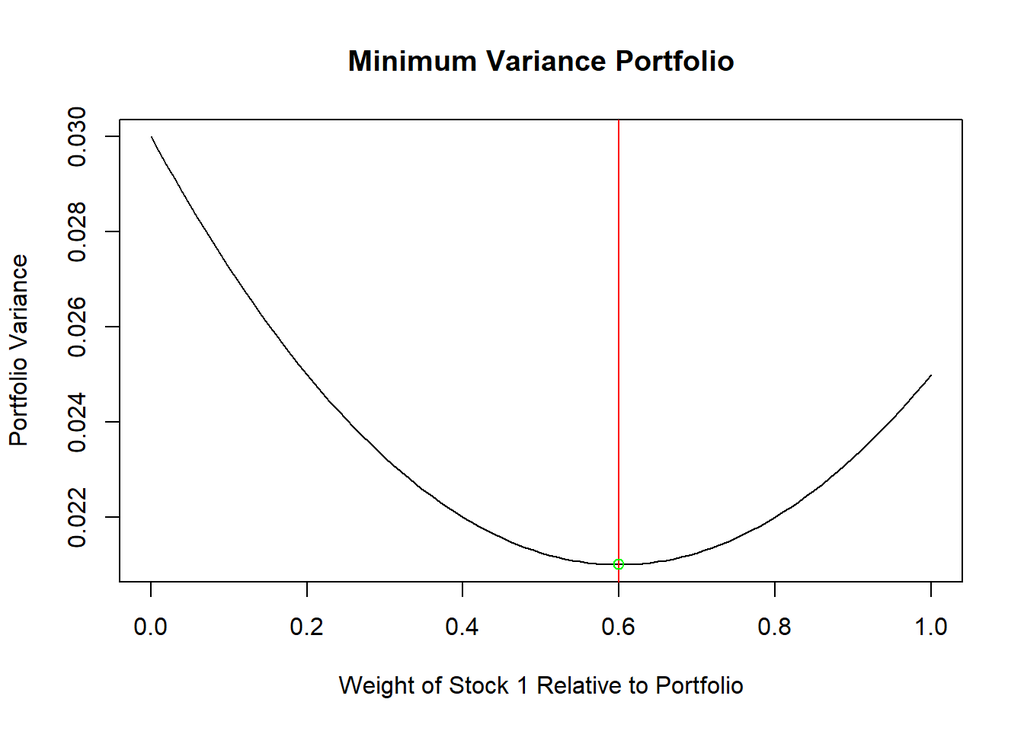

```r
# The Variance function of the portfolio
fVar <- function(m1) var_rStock1 * m1^2 + var_rStock2 * (1 - m1)^2 + 2 * m1 * (1 - m1) * cov_rStock1_rStock2

# Set the weighting
m1 <- .6
m2 <- .4

# Plot of the variance function with respect to w1.
w1 <- seq(0, 1, .05)
plot(fVar, w1, xlab = "Weight of Stock 1 Relative to Portfolio", ylab = "Portfolio Variance", main = "Minimum Variance Portfolio"); abline(v = m1, col = "red")
points(m1, fVar(m1), col='green')
```

We see indeed the minimum is at $m_1 = 0.6$

Thus, the optimum weights of each stocks in the portfolio to satisfy the objective of minimum risk is:

| Asset | Weight |
| --- | --- |
| Stock 1 | 60% |
| Stock 2 | 40% |